# Assignment 3b

- Show All Code
- Hide All Code
- View Source

Author

Anastasiia Gmyrina

## Approach

For this assignment I will use a time series dataset with daily sales for multiple product categories. I think it will be a clear easy example for calculating window functions across different product categories. I plan to:

- **Year-to-date average.** Calculate the average daily sales from the beginning of the year through each date for each product category.
- **6-day moving average.** Calculate the average sales for the current day and the previous five days for each product category.
- **Compare the results.** Look at how the year-to-date and 6-day moving averages change over time for each category.

One challenge I expect is making sure the dates are in the correct order and that the calculations are done separately for each product category. I will also need to handle the first five days, when there is no data yet to calculate a 6-day moving average.

## Data loading and preparation

For this assignment, I will use a retail sales dataset containing transactions from three product categories: Beauty, Clothing, and Electronics. The dataset includes transaction dates and total sales amounts, which I will use to calculate daily sales for each category and apply window functions.

https://github.com/antristesse/DATA607/blob/main/week3/retailsales2023.csv

```r
library(dplyr)
library(tidyr)
library(ggplot2)
sales <- read.csv(
  "https://raw.githubusercontent.com/antristesse/DATA607/refs/heads/main/week3/retailsales2023.csv"
)
head(sales)
```

|  | ID | Date | Customer_ID | Gender | Age | Product_Category | Quantity | Price | Total_Amount | X | X.1 | X.2 | X.3 | X.4 |
| --- | --- | --- | --- | --- | --- | --- | --- | --- | --- | --- | --- | --- | --- | --- |
| 1 | 1 | 11/24/2023 | CUST001 | Male | 34 | Beauty | 3 | 50 | 150 | NA | NA | NA | NA | NA |
| 2 | 2 | 2/27/2023 | CUST002 | Female | 26 | Clothing | 2 | 500 | 1000 | NA | NA | NA | NA | NA |
| 3 | 3 | 1/13/2023 | CUST003 | Male | 50 | Electronics | 1 | 30 | 30 | NA | NA | NA | NA | NA |
| 4 | 4 | 5/21/2023 | CUST004 | Male | 37 | Clothing | 1 | 500 | 500 | NA | NA | NA | NA | NA |
| 5 | 5 | 5/6/2023 | CUST005 | Male | 30 | Beauty | 2 | 50 | 100 | NA | NA | NA | NA | NA |
| 6 | 6 | 4/25/2023 | CUST006 | Female | 45 | Beauty | 1 | 30 | 30 | NA | NA | NA | NA | NA |

I selected the date, product category, and total sales amount from the original dataset and renamed the columns. I converted the date column to a date format and filtered the data to 2023. Since there can be multiple transactions for the same category on the same day, I grouped the data by date and category and summed the sales to calculate total daily sales for each category.

```r
daily_sales <- sales %>%
  select(
    date = Date,
    category = Product_Category,
    sales = Total_Amount) %>%
  mutate(date = as.Date(date, format = "%m/%d/%Y")) %>%
  filter(format(date, "%Y") == "2023") %>%
  group_by(date, category) %>%
  summarise(daily_sales = sum(sales),.groups = "drop") %>%
  arrange(category, date)

head(daily_sales)
```

| date | category | daily_sales |
| --- | --- | --- |
| 2023-01-01 | Beauty | 0 |
| 2023-01-02 | Beauty | 0 |
| 2023-01-03 | Beauty | 0 |
| 2023-01-04 | Beauty | 90 |
| 2023-01-05 | Beauty | 50 |
| 2023-01-06 | Beauty | 0 |

## Year-To-Date average

```r
daily_sales <- daily_sales %>%
  group_by(category) %>%
  mutate(ytd_avg = round(cummean(daily_sales), 2))
head(daily_sales)
```

| date | category | daily_sales | ytd_avg |
| --- | --- | --- | --- |
| 2023-01-01 | Beauty | 0 | 0.00 |
| 2023-01-02 | Beauty | 0 | 0.00 |
| 2023-01-03 | Beauty | 0 | 0.00 |
| 2023-01-04 | Beauty | 90 | 22.50 |
| 2023-01-05 | Beauty | 50 | 28.00 |
| 2023-01-06 | Beauty | 0 | 23.33 |

## 6-day average

I used https://rpubs.com/SurreyDataGirl/moving-averages as a reference for calculating moving averages in R. The article demonstrates how `rollmean()`can be used to calculate moving averages over a specified window, which I adapted to calculate the 6-day moving average required for this assignment.

```r
library(zoo)
daily_sales <- daily_sales %>%
  group_by(category) %>%
  mutate(moving_avg_6 = round(rollmean(daily_sales, k = 6, align = "right", fill = NA),2))
head(daily_sales)
```

| date | category | daily_sales | ytd_avg | moving_avg_6 |
| --- | --- | --- | --- | --- |
| 2023-01-01 | Beauty | 0 | 0.00 | NA |
| 2023-01-02 | Beauty | 0 | 0.00 | NA |
| 2023-01-03 | Beauty | 0 | 0.00 | NA |
| 2023-01-04 | Beauty | 90 | 22.50 | NA |
| 2023-01-05 | Beauty | 50 | 28.00 | NA |
| 2023-01-06 | Beauty | 0 | 23.33 | 23.33 |

## Comparison

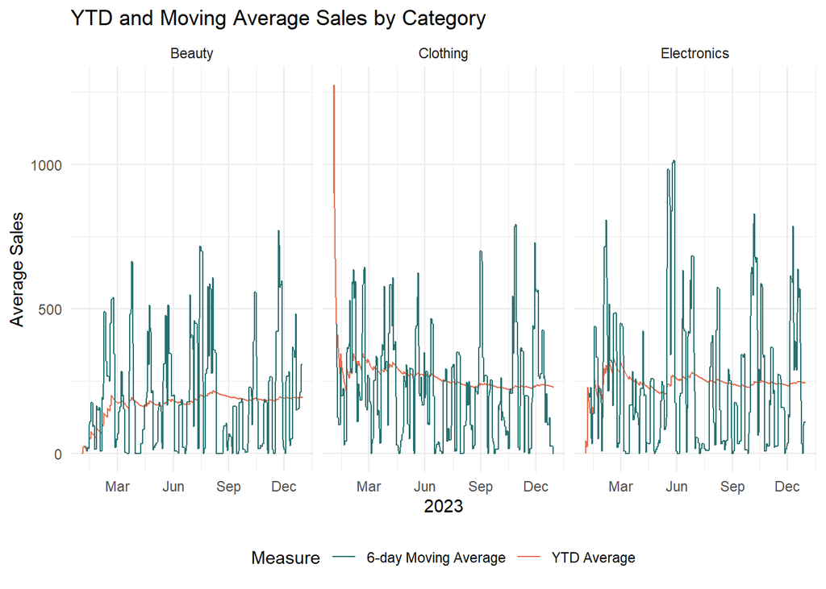

```r
ggplot(daily_sales, aes(x = date)) +
  geom_line(aes(y = ytd_avg,color = "YTD Average")) +
  geom_line(aes(y = moving_avg_6, color = "6-day Moving Average")) +
  facet_wrap(~ category) +
  scale_x_date(date_breaks = "3 months", date_labels = "%b") +
  scale_color_manual(values = c("YTD Average" = "#E76F51","6-day Moving Average" = "#287271")) +
  labs(
    title = "YTD and Moving Average Sales by Category",
    x = "2023",
    y = "Average Sales",
    color = "Measure") +
  theme_minimal() +
  theme(legend.position = "bottom")
```

The comparison shows that the YTD average is relatively smooth and stable for all three product categories because it includes all observations from the beginning of the year. The 6-day moving average changes much more over time because it only uses the six most recent observations, making it more sensitive to short-term changes in sales.